# Project 1

The code below produces two graphs showing daily COVID-19 cases and deaths for the UK, US, and Canada. This code filters the data for these three countries, selects the relevant columns (location, date, new_cases, and new_deaths) to calculate her 7-day moving average of new cases and new deaths . Next, use ggplot2 to create a bar chart of the daily number of new infections and new deaths, and a dashed line for the 7-day moving average.

Overall, the code allows you to quickly visualize and compare daily COVID-19 cases and deaths across multiple countries to gain insight into the evolution of the pandemic and the effectiveness of public health interventions.

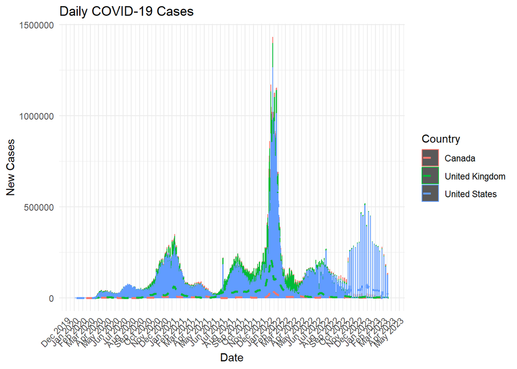

```r
# Calculate 7-day moving average for new cases and new deaths
selected_data <- selected_data %>%
  group_by(location) %>%
  mutate(avg_new_cases = rollmeanr(new_cases, k = 7, fill = NA),
         avg_new_deaths = rollmeanr(new_deaths, k = 7, fill = NA, align = "right"))

# Plot daily new cases and new deaths over time
ggplot(selected_data, aes(x = date, y = new_cases, color = location)) +
  geom_bar(stat = "identity", width = 0.5) +
  geom_line(aes(y = avg_new_cases), size = 1, linetype = "dashed") +
  labs(title = "Daily COVID-19 Cases",
       x = "Date",
       y = "New Cases",
       color = "Country") +
  scale_x_date(date_breaks = "1 month", date_labels = "%b %Y") +
  theme_minimal() +
  theme(axis.text.x = element_text(angle = 45, hjust = 1))
```

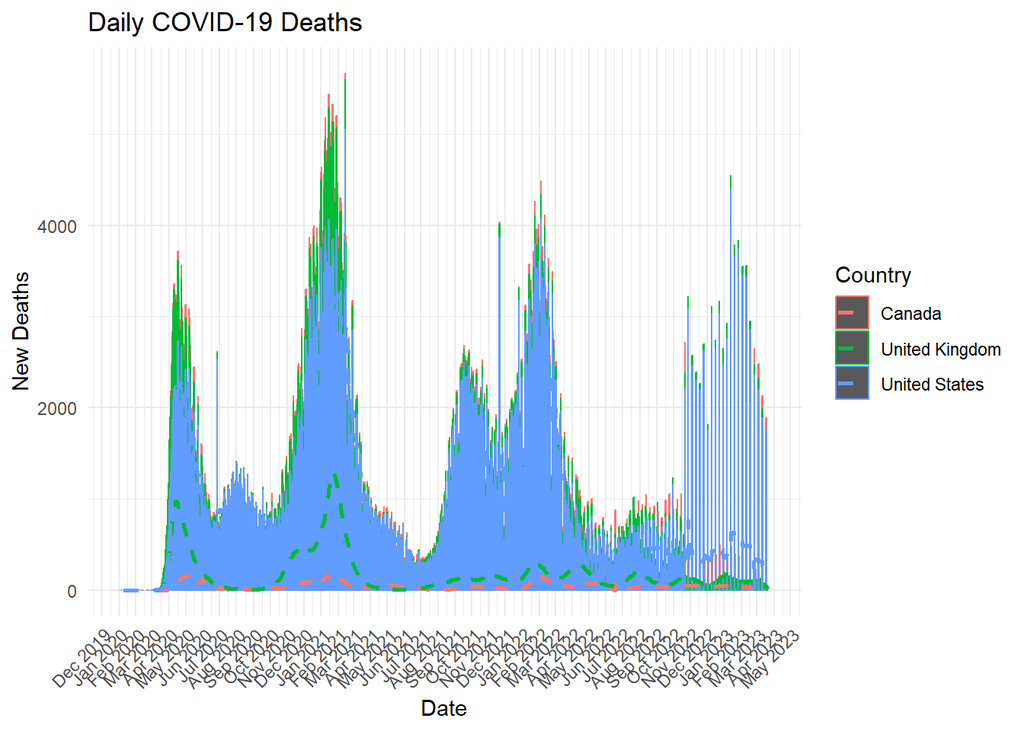

```r
ggplot(selected_data, aes(x = date, y = new_deaths, color = location)) +
  geom_bar(stat = "identity", width = 0.5) +
  geom_line(aes(y = avg_new_deaths), size = 1, linetype = "dashed") +
  labs(title = "Daily COVID-19 Deaths",
       x = "Date",
       y = "New Deaths",
       color = "Country") +
  scale_x_date(date_breaks = "1 month", date_labels = "%b %Y") +
  theme_minimal() +
  theme(axis.text.x = element_text(angle = 45, hjust = 1))
```

**COVID-19 Total Vaccination**

The graph provides a clear visual representation of the global vaccination effort against COVID-19. It highlights the progress that has been made in vaccinating millions of people around the world and the rapid increase in vaccinations over time. However, the graph also underscores the ongoing challenges in ensuring equitable access to vaccines and the need for continued global cooperation to end the pandemic.

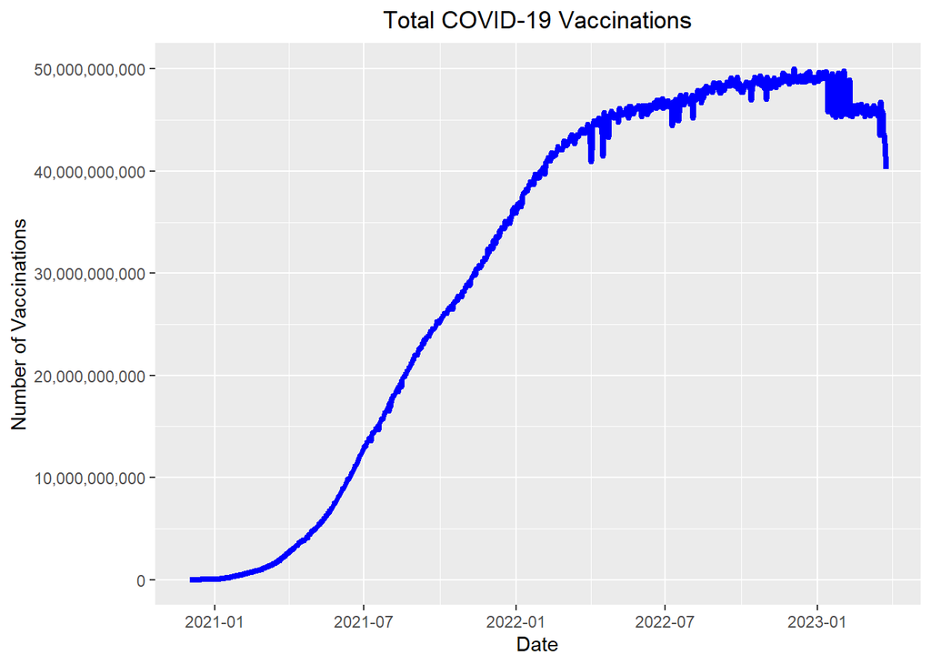

```r
# Convert date column to date format
vaccination_data$date <- as.Date(vaccination_data$date)

# Plot total vaccinations over time
total_vaccinations <- vaccination_data %>%
  group_by(date) %>%
  summarize(total_vaccinations = sum(total_vaccinations, na.rm = TRUE))

ggplot(total_vaccinations, aes(x = date, y = total_vaccinations)) +
  geom_line(size = 1.5, color = "blue") +
  labs(title = "Total COVID-19 Vaccinations", x = "Date", y = "Number of Vaccinations") +
  scale_y_continuous(labels = comma) +
  theme(plot.title = element_text(hjust = 0.5))
```

**COVID-19 Daily Vacination**

The graph provided by the code shows the daily number of COVID-19 vaccinations administered over time. The x-axis represents the date, while the y-axis represents the number of vaccinations administered each day worldwide.

The graph provides an important perspective on the pace of the global vaccination effort against COVID-19. It highlights the significant progress that has been made in administering millions of vaccinations each day, but also underscores the ongoing challenges in ensuring equitable access to vaccines and the need for continued global cooperation to end the pandemic.

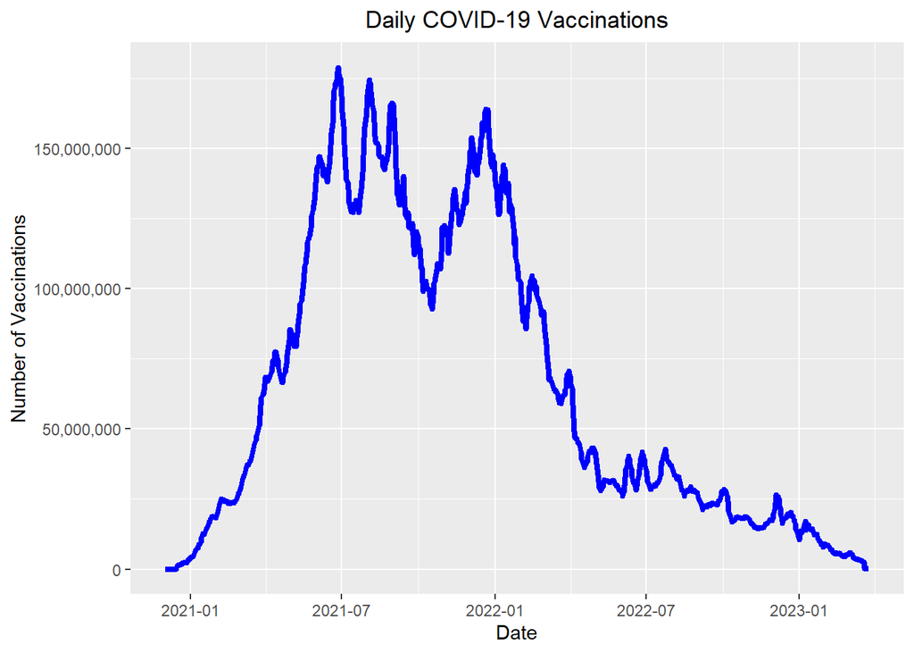

```r
# Plot daily vaccinations
daily_vaccinations <- vaccination_data %>%
  group_by(date) %>%
  summarize(daily_vaccinations = sum(daily_vaccinations, na.rm = TRUE))

ggplot(daily_vaccinations, aes(x = date, y = daily_vaccinations)) +
  geom_line(size = 1.5, color = "blue") +
  labs(title = "Daily COVID-19 Vaccinations", x = "Date", y = "Number of Vaccinations") +
  scale_y_continuous(labels = comma) +
  theme(plot.title = element_text(hjust = 0.5))
```

**Total COVID-19 Vacination By Country**

The graph provides important insights into the global vaccination effort against COVID-19 and the varying levels of progress made by different countries. It underscores the need for continued global cooperation and equitable access to vaccines to end the pandemic.

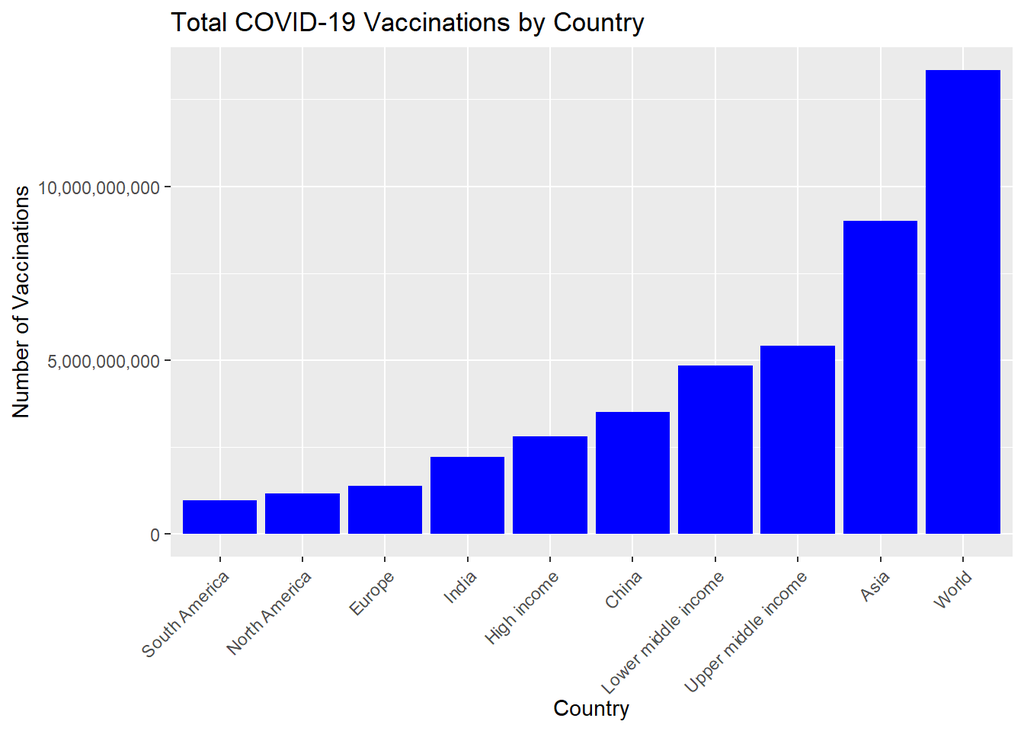

```r
# Convert date column to Date format
vaccination_data$date <- ymd(vaccination_data$date)

# Filter out rows with missing total vaccinations data
vaccination_data <- vaccination_data %>%
  filter(!is.na(total_vaccinations))

# Plot total vaccinations by country
top_countries <- vaccination_data %>%
  group_by(location) %>%
  summarize(total_vaccinations = max(total_vaccinations, na.rm = TRUE)) %>%
  ungroup() %>%
  top_n(10)

ggplot(top_countries, aes(x = fct_reorder(location, total_vaccinations), y = total_vaccinations)) +
  geom_bar(stat = "identity", fill = "blue") +
  labs(title = "Total COVID-19 Vaccinations by Country", x = "Country", y = "Number of Vaccinations") +
  scale_y_continuous(labels = comma) +
  theme(axis.text.x = element_text(angle = 45, hjust = 1))
```

**COVID-19 Vaccinations By Manufacturer And Country**

The graph shows the total number of COVID-19 vaccine doses administered by vaccine manufacturer and country for the top 10 countries in terms of total doses. The x-axis shows the countries, and the y-axis shows the total number of doses administered in millions. The bars are color-coded by the vaccine manufacturer.

The graph provides a useful overview of the distribution of COVID-19 vaccines by manufacturer and country for the top 10 countries in terms of total doses. It highlights the differences in vaccine usage across countries and can help inform policy decisions related to vaccine procurement and distribution.

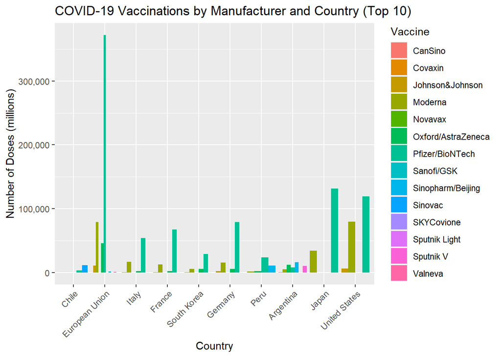

```r
# Load data
vaccine_manufacturer_data <- read.csv("https://raw.githubusercontent.com/owid/covid-19-data/master/public/data/vaccinations/vaccinations-by-manufacturer.csv")

# Calculate total doses by manufacturer and location
total_doses_by_manufacturer <- vaccine_manufacturer_data %>%
  group_by(location, vaccine) %>%
  summarize(total_doses = sum(total_vaccinations)) %>%
  ungroup() %>%
  mutate(total_doses_millions = total_doses / 1000000)

# Select top 10 countries by total doses
top_10_countries <- total_doses_by_manufacturer %>%
  group_by(location) %>%
  summarize(total_doses = sum(total_doses_millions)) %>%
  top_n(10)

# Filter data to only include top 10 countries
total_doses_top_10 <- total_doses_by_manufacturer %>%
  filter(location %in% top_10_countries$location)

# Plot total doses by manufacturer and location for top 10 countries
ggplot(total_doses_top_10, aes(x = fct_reorder(location, total_doses_millions), y = total_doses_millions, fill = vaccine)) +
  geom_bar(stat = "identity", position = "dodge") +
  labs(title = "COVID-19 Vaccinations by Manufacturer and Country (Top 10)", x = "Country", y = "Number of Doses (millions)", fill = "Vaccine") +
  scale_y_continuous(labels = comma) +
  theme(axis.text.x = element_text(angle = 45, hjust = 1))
```